# Bladee: A Genre Analysis

### by Caleb Yoshida

##### Published May 16, 2022

1. Introduction
2. Data Collection
   1. Rationale
   2. Defining Functions
   3. API Calls and Web Scraping
   4. Missing Data
3. Data Analysis
   1. Review
   2. Popularity by Genre
   3. Popularity by Number of Genres
   4. Linear Regression
4. Conclusion

## 1. Introduction

Bladee (pronounced "blade") is a Swedish rapper, singer, songwriter, and record producer, among other endeavors. His music, known to be industrial, etherial, experimental, and dark, has a massive cult following and has been known to [not fit cleanly](https://www.miamistudent.net/article/2021/09/bladee-artist-review) into the modern music industry's definitions of genre. His [musical influences](https://en.wikipedia.org/wiki/Bladee#Musical_style) are known to vary greatly, ranging from Chief Keef to The Beach Boys, and his auto-tuned, emotional, and contemporary sound manifests itself in an inconceivable number of ways throughout his catalog. His unprecedented music has garnered a dedicated core fanbase and widespread familiarity for some of his more popular songs. As is normal for any artist, his catalog has tracks of varying degrees of popularity. Because of his variety in both style and popularity, in this report, we will explore the relationship between these factors.

## 2. Data Collection

#### 2.1 Rationale

We will be comparing the songs in Bladee's discography on an individual basis. In order to quantify a song's musical style and popularity, we will use data from existing sources.

To find a song's popularity, we will look at [Spotify](https://www.spotify.com/)'s "popularity" value, showing the song's popularity on Spotify on a scale of 0 to 100. We will assume that a song's popularity on Spotify represents its popularity overall. Since Bladee's discography is available on all streaming platforms, we will assume that there is no discrepancy between Spotify and SoundCloud, for example, which is known for hosting content that cannot exist on other platforms for copyright reasons. We will also assume that there is no significant difference in users' preferences across all streaming platforms, such as Apple Music, for convenience. We will not look at music charts or awards because Bladee is not popular enough for that data to have any significance.

To find a song's musical style, we will look at [Genius](https://genius.com/)'s tags for each song. Each song has about 0-10 tags, a phrase describing the genre or stylistic elements of a song. All of Genius' data is crowdsourced and peer-reviewed. We will assume that all data is accurate and that a similar level of effort and description was applied to each song.

#### 2.2 Defining Functions

First, we will define some functions.

```python
import json
import base64
import requests
# util.py contains important variables
from util import *

# Request access token from Spotify API
# spotify_get makes a get request to the specified API endpoint
def spotify_get_access_token(client_id, client_secret):
    url = 'https://accounts.spotify.com/api/token'
    auth = base64.b64encode(f'{client_id}:{client_secret}'.encode('ascii')).decode('ascii')
    headers = {'Authorization': f'Basic {auth}'}
    data = {'grant_type': 'client_credentials'}
    return requests.post(url, headers=headers, data=data).json()['access_token']
spotify_access_token = spotify_get_access_token(spotify_client_id, spotify_client_secret)
def spotify_get(endpoint, params):
    url = 'https://api.spotify.com/v1' + endpoint
    headers = {'Authorization': f'Bearer {spotify_access_token}'}
    return requests.get(url, headers=headers, params=params).json()

# Request access token from Genius API
# genius_get makes a get request to the specified API endpoint
def genius_get_access_token(client_id, client_secret):
    url = 'https://api.genius.com/oauth/token'
    data = {'client_id': client_id, 'client_secret': client_secret, 'grant_type': 'client_credentials'}
    return requests.post(url, data=data).json()['access_token']
genius_access_token = genius_get_access_token(genius_client_id, genius_client_secret)
def genius_get(endpoint, params):
    url = 'https://api.genius.com' + endpoint
    headers = {'Authorization': f'Bearer {genius_access_token}'}
    return requests.get(url, headers=headers, params=params).json()
```

#### 2.3 API Calls and Web Scraping

We will use Spotify's catalog as reference for Bladee's discography. While the releases present on Spotify do not always represent an artist's complete catalog, we have found that this is not the case for Bladee. We will use Spotify's "album_type" classifier to find all releases classified as an 'album'. We will not consider singles or EPs as these types of releases are not always considered part of an artist's discography and often lack important context necessary to consider them fully realized releases. For example, considering a single outside of the context of an upcoming album it will be featured on does not paint a complete picture. We will also omit the deluxe version of the album "Good Luck" because the regular version is also present and the deluxe version contains remixes by other artists and producers, and thus may not be representative of Bladee and Mechatok's creative vision. (Mechatok is a producer on "Good Luck") We will consider songs that Bladee is not featured on but are on albums for which Bladee is a primary artist as they can still be considered a part of his discography.

```python
# Get albums containing Bladee's specific Spotify ID
spotify_albums = spotify_get('/artists/2xvtxDNInKDV4AvGmjw6d1/albums', {'include_groups': 'album'})['items']
spotify_album_ids = {spotify_albums[x]['name']:spotify_albums[x]['id'] for x in range(len(spotify_albums))}
del spotify_album_ids['Good Luck (Deluxe)']
```

Here, we will use our list of Spotify IDs of albums to find the tracks on each album, request Spotify's API for data on each track, request Genius' API for the genius.com URL for each track, and use BeautifulSoup to scrape each URL for the Genius tags for each track, resulting in a Pandas DataFrame with all of the songs we will analyze later.

```python
import numpy as np
import pandas as pd
from bs4 import BeautifulSoup

# genius_get_tags gets song tags by scraping provided genius.com url
def genius_get_tags(url):
    return [x.get_text() for x in BeautifulSoup(requests.get(url).content).find('div', {'class': 'SongTags__Container-xixwg3-1 bZsZHM'}).findAll('a')]

# Get tracks for each album in spotify_album_ids
# Use API calls to find column values and fill DataFrame
def scrape(album_ids):
    df = pd.DataFrame(columns=['spotify_id', 'name', 'artists', 'album', 'spotify_popularity', 'genius_url', 'genius_tags'])
    for i in album_ids:
        for j in spotify_get(f'/albums/{i}/tracks', {})['items']:
            spotify_id = j['id']
            track = spotify_get(f'/tracks/{spotify_id}', {})
            name = track['name']
            artists = [x['name'] for x in track['artists']]
            album = track['album']['name']
            spotify_popularity = track['popularity']
            genius_search = genius_get('/search', {'q': name+' '+' '.join(artists)})['response']['hits']
            if 'pageviews' in genius_search[0]['result']['stats']:
                genius_url = genius_search[0]['result']['url']
                genius_tags = genius_get_tags(genius_url)
            else:
                genius_url = np.NAN
                genius_tags = np.NAN
            df.loc[len(df)] = [spotify_id, name, artists, album, spotify_popularity, genius_url, genius_tags]
    return df

# scrape(spotify_album_ids.values()).to_csv('data.csv', index=False)
df = pd.read_csv('data.csv')
```

#### 2.4 Missing Data

Here, we will check to see if any data is missing.

```python
df[df.isna().any(axis=1)]
```

|  | spotify_id | name | artists | album | spotify_popularity | genius_url | genius_tags |
| --- | --- | --- | --- | --- | --- | --- | --- |
| 17 | 4T5wpZk3BFQjKr8ILvlQEr | Inspiration Comes | ['Bladee', 'Thaiboy Digital'] | The Fool | 42 | NaN | NaN |
| 22 | 3wIEHX36d0dMhNd7rkCzKe | Intro | ['Bladee', 'Mechatok'] | Good Luck | 27 | NaN | NaN |
| 28 | 1Gr3nRwHMZaL6pm34eM701 | Into One | ['Bladee', 'Mechatok'] | Good Luck | 33 | NaN | NaN |
| 29 | 3xJPj6HXfFZXsdlQpglSAn | Grace | ['Bladee', 'Mechatok'] | Good Luck | 26 | NaN | NaN |
| 47 | 1ULQ7j3Tt1ve1ZzAkESsAj | WONDERLAND | ['Bladee', 'Ecco2k'] | EXETER | 42 | NaN | NaN |
| 53 | 0I1aFvdF30Y6j440CE0XGV | LOVESTORY | ['Bladee', 'Ecco2k'] | EXETER | 45 | NaN | NaN |
| 59 | 1zX178V8sWozr96MrfmRun | Western Union | ['Ecco2k', 'Thaiboy Digital', 'Bladee'] | Trash Island | 43 | NaN | NaN |
| 68 | 3wUla5WsY7YnyAKAg3zdB2 | Inside Out | ['Bladee', 'Yung Lean'] | Icedancer | 46 | NaN | NaN |

We can see that we are missing data for 8 rows. The data was missing because the Genius API's search endpoint's first result for the given keywords could not be confidently identified as the correct result. Genius sometimes has song translations among the search results, which seem to be treated as separate songs. Therefore, they do not have the appropriate tags. We can exclude search results for which we are not confident that we have found the correct result based on the "pageviews" value. Incorrect results often have unusually low page views or do not have that statistic at all. The results for which the "pageviews" value seemed inaccurate were replaced with numpy.NAN. Now, we will manually fill those values from a dictionary in util.py.

```python
for k, v in missing_data.items():
    df.loc[k] = df.loc[k].tolist()[0:5]+[v, str(genius_get_tags(v))]
df.loc[missing_data.keys()]
```

|  | spotify_id | name | artists | album | spotify_popularity | genius_url | genius_tags |
| --- | --- | --- | --- | --- | --- | --- | --- |
| 17 | 4T5wpZk3BFQjKr8ILvlQEr | Inspiration Comes | ['Bladee', 'Thaiboy Digital'] | The Fool | 42 | https://genius.com/Bladee-inspiration-comes-ly... | ['Rap', 'Drill', 'Cloud Rap', 'Pop Rap', 'Trap... |
| 22 | 3wIEHX36d0dMhNd7rkCzKe | Intro | ['Bladee', 'Mechatok'] | Good Luck | 27 | https://genius.com/Bladee-and-mechatok-intro-l... | ['Pop', 'Instrumental', 'Synth-Pop', 'Sverige'... |
| 28 | 1Gr3nRwHMZaL6pm34eM701 | Into One | ['Bladee', 'Mechatok'] | Good Luck | 33 | https://genius.com/Bladee-and-mechatok-into-on... | ['Pop', 'Dance-Pop', 'Bubblegum Pop', 'Electro... |
| 29 | 3xJPj6HXfFZXsdlQpglSAn | Grace | ['Bladee', 'Mechatok'] | Good Luck | 26 | https://genius.com/Bladee-and-mechatok-grace-l... | ['Pop', 'Experimental Pop', 'Art Pop', 'Ambien... |
| 47 | 1ULQ7j3Tt1ve1ZzAkESsAj | WONDERLAND | ['Bladee', 'Ecco2k'] | EXETER | 42 | https://genius.com/Bladee-wonderland-lyrics | ['Pop', 'Art Pop', 'Alternative R&B', 'Cloud R... |
| 53 | 0I1aFvdF30Y6j440CE0XGV | LOVESTORY | ['Bladee', 'Ecco2k'] | EXETER | 45 | https://genius.com/Bladee-lovestory-lyrics | ['Pop', 'Art Pop', 'Experimental Pop', 'Scandi... |
| 59 | 1zX178V8sWozr96MrfmRun | Western Union | ['Ecco2k', 'Thaiboy Digital', 'Bladee'] | Trash Island | 43 | https://genius.com/Bladee-ecco2k-and-thaiboy-d... | ['Pop', 'Rap', 'Scandipop', 'Svensk Rap', 'Pop... |
| 68 | 3wUla5WsY7YnyAKAg3zdB2 | Inside Out | ['Bladee', 'Yung Lean'] | Icedancer | 46 | https://genius.com/Bladee-inside-out-lyrics | ['Rap', 'Trap', 'Sverige'] |

## 3. Data Analysis

#### 3.1 Review

We now have a DataFrame with complete data. The relevant columns are spotify_popularity, which shows the popularity of a song on a scale of 0 to 100, and genius_tags, which shows the tags associated with a song.

```python
df.sample(10)
```

|  | spotify_id | name | artists | album | spotify_popularity | genius_url | genius_tags |
| --- | --- | --- | --- | --- | --- | --- | --- |
| 88 | 72QEZU1irVPiifDfmgmOVn | For You | ['Bladee', 'Ecco2k'] | Red Light | 36 | https://genius.com/Bladee-and-ecco2k-plastic-s... | ['Rap', 'Alternative R&B', 'Emo Rap', 'Cloud R... |
| 11 | 1zoTGEJRVGu0XP7aC9LF0t | Hotel Breakfast | ['Bladee'] | The Fool | 55 | https://genius.com/Bladee-hotel-breakfast-lyrics | ['Rap', 'Cloud Rap', 'Trap', 'Scandinavia', 'S... |
| 129 | 0BRAPjnIOeVI48xwf9BTmV | Who Goes There | ['Bladee'] | Eversince | 37 | https://genius.com/Bladee-who-goes-there-lyrics | ['Rap', 'Svensk Rap', 'Scandinavia', 'Drill', ... |
| 85 | 4NBHhKDJqBeKyZ2YxKmaMf | Fake News | ['Bladee'] | Red Light | 30 | https://genius.com/Bladee-fake-news-lyrics | ['Rap', 'Scandinavia', 'Sverige', 'Svensk Rap'] |
| 84 | 4fI9NDKGs0LXj3GRdH1sCX | Westfield | ['Bladee'] | Red Light | 33 | https://genius.com/Bladee-westfield-lyrics | ['Rap', 'Scandinavia', 'Sverige', 'Svensk Rap'] |
| 118 | 3qkkPxDicC81xp9gBYTdI1 | Botox Lips | ['Bladee'] | D&G | 25 | https://genius.com/Bladee-botox-lips-lyrics | ['Pop', 'Svensk Rap', 'Sverige', 'Art Pop', 'C... |
| 142 | 5taIL6mVAAjuN6tCSDIDqI | Safehouse | ['Bladee'] | Gluee | 33 | https://genius.com/Bladee-safehouse-lyrics | ['Rap', 'Pop Rap', 'Trap', 'Cloud Rap'] |
| 18 | 70c4vZbX5Yemtn3Ff7wlfr | egobaby | ['Bladee'] | The Fool | 51 | https://genius.com/Bladee-egobaby-lyrics | ['Rap', 'Pop Rap', 'Cloud Rap', 'Trap', 'Scand... |
| 70 | 6TiDejyzmUKOyKLk7hQGJn | Jaws | ['Bladee'] | Icedancer | 44 | https://genius.com/Bladee-jaws-lyrics | ['Rap', 'Trap'] |
| 114 | 2F9bO5QEATSWnwtsGrxXCy | Suffocation | ['Bladee'] | D&G | 26 | https://genius.com/Bladee-suffocation-lyrics | ['Rap', 'Trap'] |

#### 3.2 Popularity By Genre

```python
df2 = pd.DataFrame(columns=['spotify_popularity', 'genius_tag'])
for i, row in df.iterrows():
    for j in [x.replace("'", "") for x in row['genius_tags'].strip('][').split(', ')]:
        df2.loc[len(df2)] = [row['spotify_popularity'], j]
df2['spotify_popularity'] = df2['spotify_popularity'].astype(int)
```

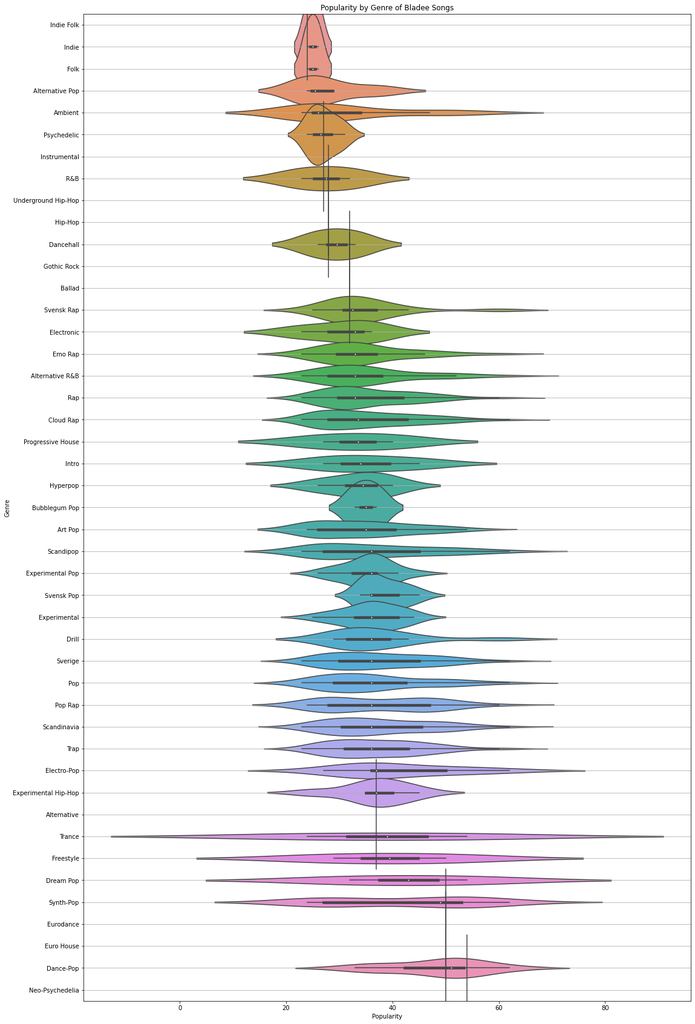

```python
import seaborn as sns
import matplotlib.pyplot as plt

fig, ax = plt.subplots(figsize=(18,30))
sns.violinplot(x=df2['spotify_popularity'], y=df2['genius_tag'], width=5.0, orient='h', order=df2.groupby(['genius_tag'])['spotify_popularity'].median().sort_values().index, ax=ax)
ax.yaxis.grid(True)
plt.title('Popularity by Genre of Bladee Songs')
plt.ylabel('Genre')
plt.xlabel('Popularity')
plt.show()
```

We should disregard the categories with only one data point. Based on the graph, it seems that in Bladee's discography, the most popular genres are Dance-Pop, Synth-Pop, and Dream Pop. It seems that the least popular genres are Indie, Folk, and Alternative Pop.

#### 3.3 Popularity by Number of Genres

It will also be interesting to see how the number of genius_tags, or genres, influences a track's popularity. It is possible that a greater number of tags represents a more eclectic song, drawing from a greater range of influences. We will do this by organizing our data into a new DataFrame then visualizing it using a scatter plot.

```python
df3 = pd.DataFrame(columns=['spotify_popularity', 'genius_tags_count'])
for i, row in df.iterrows():
    df3.loc[len(df3)] = [row['spotify_popularity'], len([x.replace("'", "") for x in row['genius_tags'].strip('][').split(', ')])]
df3['spotify_popularity'] = df2['spotify_popularity'].astype(int)
```

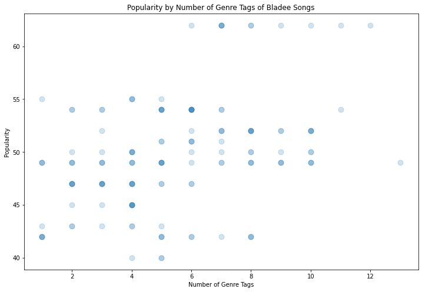

```python
fig, ax = plt.subplots(figsize=(12,8))
plt.scatter(x=df3['genius_tags_count'], y=df3['spotify_popularity'], alpha=.2, s=80)
plt.title('Popularity by Number of Genre Tags of Bladee Songs')
plt.ylabel('Popularity')
plt.xlabel('Number of Genre Tags')
plt.show()
```

It is not immediately obvious what the relationship between these variables is, so we should use a statistical model to find out.

#### Linear Regression

Now, we will use linear regression to determine whether there is a predictive relationship between genius_tags_count and spotify_popularity.

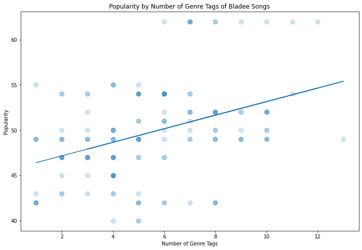

```python
from sklearn.linear_model import LinearRegression

model = LinearRegression().fit([[x] for x in df3['genius_tags_count']], [[y] for y in df3['spotify_popularity']])

fig, ax = plt.subplots(figsize=(12,8))
ax.plot([[x] for x in df3['genius_tags_count'].unique()], [y for [y] in model.predict([[x] for x in df3['genius_tags_count'].unique()])])
plt.scatter(x=df3['genius_tags_count'], y=df3['spotify_popularity'], alpha=.2, s=80)
plt.title('Popularity by Number of Genre Tags of Bladee Songs')
plt.ylabel('Popularity')
plt.xlabel('Number of Genre Tags')
plt.show()
```

## 4. Conclusion

It would be interesting to compare how certain combinations of genres affect a song's popularity. It would also be interesting to use data from the website [Every Noise at Once](https://everynoise.com/), where relationships between genres are represented visually.

This is an analysis that will likely change over time, so it is important to document these data as a snapshot in time, preserved for appreciation and comparison later.